# Data Handling: Import, Cleaning and Visualisation

Lecture 4: Data Structures: Rectangular Data

Dr. Aurélien Sallin

2026-10-08

# Recap

## Goals of last lecture

1. Get the basics of **data processing**
2. Learn what **binary** and **hexadecimal** systems are
3. See why **encoding** is crucial for any data project
4. Realize that both code and data are just **text** at their core
5. Know the basic components of a **computing environment** (self-study 🔎)

## From binary to `.txt`

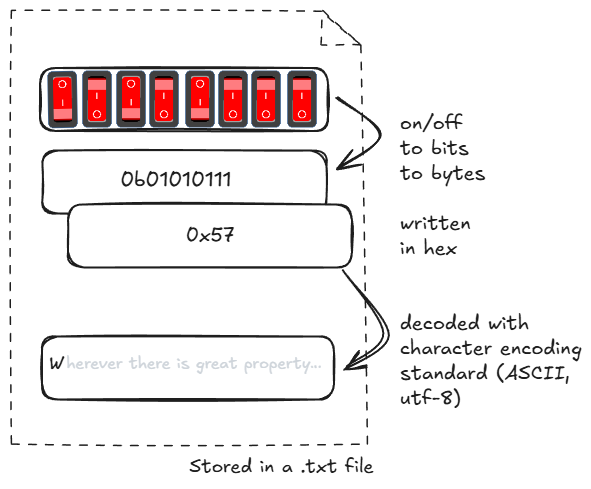

#### Binary:

- Base 2. Only two signs: `0`, `1`.
- Columns: $2^0=1$, $2^1=2$, $2^2=4$, and so forth.
- Floating point numbers

#### Hexadecimal:

- 16 symbols
- Base 16.
- `0`-`9` (used like in the decimal system) and `A`-`F` (for the numbers 10 to 15).

## Character encodings

- *Standards* define how `0`s and `1`s correspond to specific characters of different human languages.
- Coded character sets that map unique numbers (in the end in binary coded values) to each character in the set.
- For example, ASCII (American Standard Code for Information Interchange) or *utf-8*.

## Character encodings

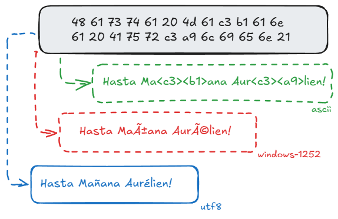

- **Recognize an encoding issue when it occurs!**
- Problem occurs right at the beginning of the *data pipeline*!

## Components of a standard computing environment

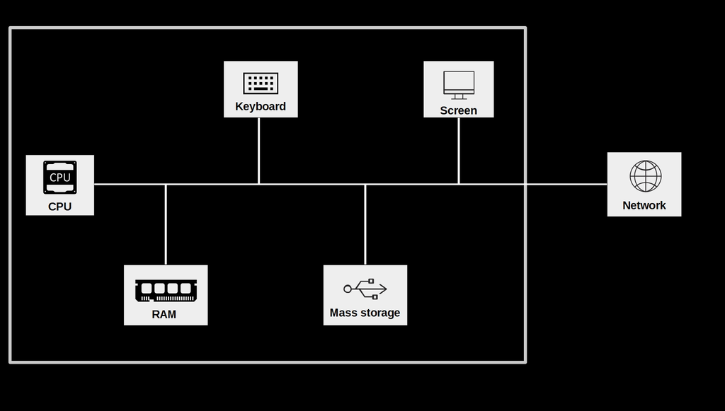

Reading: please read the document “Data Processing Basics”. This is exam relevant! 🔎

## Exercise: a website scraper

Last time, we saw that a webpage is nothing but **text** (HTML). We looked at its hexadecimal representation. The size in RAM of our “economist” html object was `468048 bytes`.

#### From hexadecimal

```r
library(httr)
economist <- GET("https://www.economist.com/")
head(content(economist, as = "raw"), 20)
```

```
 [1] 3c 21 44 4f 43 54 59 50 45 20 68 74 6d 6c 3e 3c 68 74 6d 6c
```

#### … to html…

```r
head(content(economist, as = "text"))
```

```
"<!DOCTYPE html><html lang=\"en\"><head>
```

#### … to website

[figure not shown]

# Warm-up

## Warm-up 1&2

#### What is 234 in binary? Please answer exact response with format 00000000.

#### What is 22C (hex) in decimal?

## Warm-up 3

Consider the following `R` function:

```r
muLtip <- function(n, limit) {

  product <- 1
  counter <- 1

  while (counter <= n) {
    product <- product * counter
    if (product > limit) {
      return(product)
    }
    counter <- counter + 1
  }
  return(product)
}
```

What is `muLtip(5,20)`?

## Warm-up 4: question from lecture 3

#### Advantages (when working with binary numbers)

1. Shorter than raw binary representation
2. Much easier to translate back and forth between binary and hexadecimal than binary and decimal.

*WHY?*

😆

## Warm-up 4: Why?

##### One hex digit = exactly 4 bits, because $2^4 = 16$

Translating between binary and hexadecimal is straightforward: each hexadecimal digit maps directly to a group of **4 binary digits**

| Decimal | Binary | Hex |
| --- | --- | --- |
| 0 | 0000 | 0 |
| 1 | 0001 | 1 |
| … | … | … |
| 9 | 1001 | 9 |
| 10 | 1010 | A |
| … | … | … |
| 15 | 1111 | F |

#### Example: the letter W

`0101 0111` → `5` `7` → `0x57`, just regroup

# Course organization

## Group formation for the group project

#### Timeline:

- **09.10.2026**: group formation opens on **Canvas**
- **16.10.2026**: deadline for group formation

#### Important:

- Groups of 5️⃣ students, compulsory for the group project.
- No group (or an incomplete group) by 16.10? We will assign you to one.

##### Once formed, groups stay fixed for the whole project.

# Today

## Our story today: from text to data

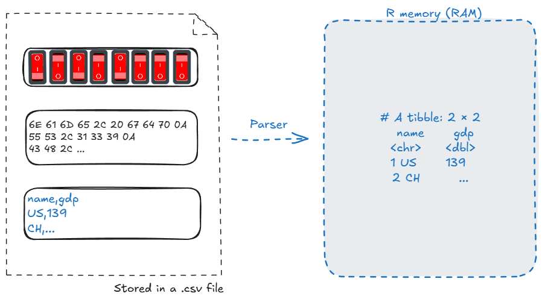

- Text encodes meaning
- Files encode structure (→ Structured Files (CSV))
- R parses structure into memory. (→ R Parsing → R Data Structures)

## Goals for today

- Understand how we **import** and structure data from text files
- Learn **data structures** in R
- Understand and manipulate **rectangular data formats**

# From text to data structure

## Structured Data Formats

We are used to not thinking about the formats of our data… and let the computer choose what to do with data when we click on a file.

##### All data are text files, but with standardized structure.

- Text represents structured data
- **Special characters** define the structure.
- More complex **syntax**, more complex structures can be represented…

## Data take different structures depending on their purpose

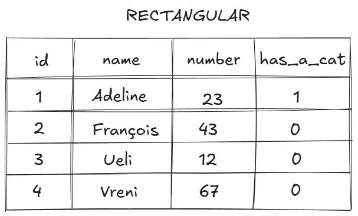

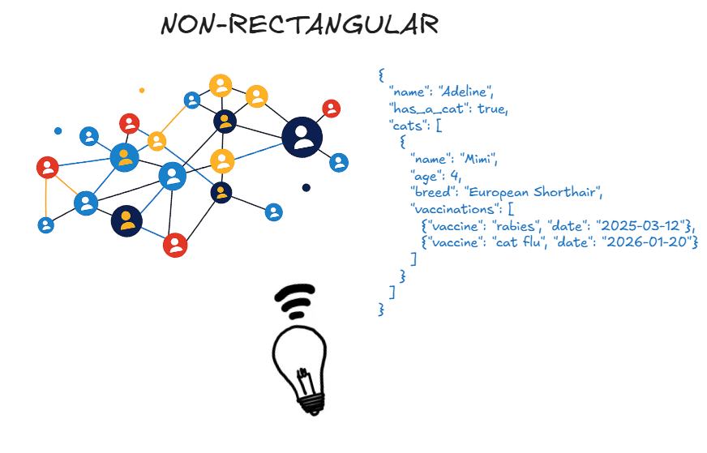

## Rectangular data

- **Rectangular data** refers to a data structure where information is organized into **rows and columns**.
  - Each row represents an observation or instance of the data.
  - Each column represents a variable or feature of the data.

## Rectangular data

- **Rectangular data** refers to a data structure where information is organized into **rows and columns**.
  - CSV (typical for rectangular/table-like data) and variants of CSV (tab-delimited, fix length etc.)
  - Excel spreadsheets (`.xlsx`)
  - Formats specific to statistical software (SPSS: `.sav`, STATA: `.dta`, etc.)
  - Built-in R datasets
  - …

## Non-rectangular data

- **Hierarchical data** (xml, html, json, etc.)
  - XML and JSON (useful for complex/high-dimensional data sets)
  - HTML (a markup language to define the structure and layout of webpages)
- **Network data**
- Unstructured **text** data
- **Internet-of-Things** data
- **Images/Pictures** data

# Rectangular data formats

## Table-like formats

Example: `ch_gdp.csv`.

```
year,gdp_chf
1980,184
1985,244
1990,331
1995,374
2000,422
2005,464
```

#### What is the structure?

## Table-like formats

- Reocurring pattern:
  - Special character `,`
  - New lines
  - Table is visible from structure in raw text file…

#### How can we instruct a computer to read this text as a 6-by-2 table?

## Using a simple parser algorithm

##### A **parser** is a sequence of rules of how to distinguish columns and rows when all that a computer can do is sequentially read one character after the other.

- Possible if we can agree on certain **standards/convention** of how data structured as a table/matrix is stored in a text file.

##### The CSV standard (‘Comma-Separated Values’, `.csv`)

- Commas separate values (other delimiters like `;`, tabs, etc. possible)
- New lines separate rows/observations

## Using a simple CSV parser

#### Look for…

- Commas delimit values/fields in a row
- Line breaks indicate the end of a row

```
year,gdp_chf
1980,184
1985,244
1990,331
1995,374
2000,422
2005,464
```

```
ef bb bf 79 65 61 72 2c 67 64 70 5f 63 68 66 0a
31 39 38 30 2c 31 38 34 0a
31 39 38 35 2c 32 34 34 0a
31 39 39 30 2c 33 33 31 0a
31 39 39 35 2c 33 37 34 0a
32 30 30 30 2c 34 32 32 0a
32 30 30 35 2c 34 36 34
```

## CSVs and fixed-width format

- Common format to store and transfer data.
- Very common in a data analysis context.
- Natural format/structure when the dataset can be thought of as a table.

#### How can `R` read this structure?

# Importing Rectangular Data from Text-Files

## From text to table

#### The file `stock_prices.csv`

(not real market data 💸)

```
date,time,ticker,company,close_chf,volume,dividend_paid
2026-10-01,17:30,NESN,Nestlé,78.42,4210350,FALSE
2026-10-01,17:30,UBSG,UBS,27.15,9876012,FALSE
2026-10-01,17:30,NOVN,Novartis,96.80,3120457,TRUE
2026-10-02,17:30,NESN,Nestlé,78.90,3988120,FALSE
2026-10-02,17:30,UBSG,UBS,27.40,10233990,FALSE
2026-10-02,17:30,NOVN,Novartis,95.95,2874001,FALSE
```

#### After being parsed in `R`

```r
library(readr)
stocks <- read_csv("data/stock_prices.csv")
stocks
```

```
# A tibble: 6 × 7
  date       time   ticker company  close_chf   volume dividend_paid
  <date>     <time> <chr>  <chr>        <dbl>    <dbl> <lgl>
1 2026-10-01 17:30  NESN   Nestlé        78.4  4210350 FALSE
2 2026-10-01 17:30  UBSG   UBS           27.2  9876012 FALSE
3 2026-10-01 17:30  NOVN   Novartis      96.8  3120457 TRUE
4 2026-10-02 17:30  NESN   Nestlé        78.9  3988120 FALSE
5 2026-10-02 17:30  UBSG   UBS           27.4 10233990 FALSE
6 2026-10-02 17:30  NOVN   Novartis      96.0  2874001 FALSE
```

## Parsing CSVs in R with `readr`

Use `read_csv()` from the `readr` package instead of `read.csv()` from the basic R distribution

- `readr` offers functions for all common rectangular data formats (`read_tsv()` for tab-separated, `read_fwf()` for fixed-width, etc.)
- More robust and faster than similar functions in basic R.
- The result is a `data frame` (or `tibble`)

[figure not shown]

- For very large files, the `data.table`-package and the `fread()` is much faster and guesses the delimiter itself.
- `readr` documentation and cheatsheet: [readr.tidyverse.org](https://readr.tidyverse.org/)

## Parsing CSVs

Recognizing columns and rows is one thing…

```
# A tibble: 6 × 7
  date       time   ticker company  close_chf   volume dividend_paid
  <date>     <time> <chr>  <chr>        <dbl>    <dbl> <lgl>
1 2026-10-01 17:30  NESN   Nestlé        78.4  4210350 FALSE
2 2026-10-01 17:30  UBSG   UBS           27.2  9876012 FALSE
3 2026-10-01 17:30  NOVN   Novartis      96.8  3120457 TRUE
4 2026-10-02 17:30  NESN   Nestlé        78.9  3988120 FALSE
5 2026-10-02 17:30  UBSG   UBS           27.4 10233990 FALSE
6 2026-10-02 17:30  NOVN   Novartis      96.0  2874001 FALSE
```

#### What else did `read_csv()` recognize?

## What else did `read_csv()` recognise?

##### The parser guesses the data type of each column from its content.

```r
library(dplyr)
glimpse(stocks)
```

```
Rows: 6
Columns: 7
$ date          <date> 2026-10-01, 2026-10-01, 2026-10-01, 2026-10-02, 2026-10-02, 2026-10-02
$ time          <time> 17:30:00, 17:30:00, 17:30:00, 17:30:00, 17:30:00, 17:30:00
$ ticker        <chr> "NESN", "UBSG", "NOVN", "NESN", "UBSG", "NOVN"
$ company       <chr> "Nestlé", "UBS", "Novartis", "Nestlé", "UBS", "Novartis"
$ close_chf     <dbl> 78.42, 27.15, 96.80, 78.90, 27.40, 95.95
$ volume        <dbl> 4210350, 9876012, 3120457, 3988120, 10233990, 2874001
$ dividend_paid <lgl> FALSE, FALSE, TRUE, FALSE, FALSE, FALSE
```

## Parsing CSV-columns

- `"12:00"`: type `character`?
- What about `c("12:00", "midnight", "noon")`?
- And now `c("12:00", "14:30", "20:01")`?

## Parsing CSV-columns

#### … Let’s test it!

```r
read_csv('A,B
         12:00, 12:00
         14:30, midnight
         20:01, noon')
```

```
# A tibble: 3 × 2
  A      B
  <time> <chr>
1 12:00  12:00
2 14:30  midnight
3 20:01  noon
```

#### How can `read_csv()` distinguish the two cases?

## Parsing CSV-columns: guess types

- `read_csv()` guesses the column type by inspecting the first 1000 rows and matching patterns: numeric, date/time, logical, character, etc.
- Under the hood `read_csv()` used the `guess_parser()`- function to determine which type the two vectors likely contain:

```r
guess_parser(c("12:00", "midnight", "noon"))
```

```
[1] "character"
```

```r
guess_parser(c("12:00", "14:30", "20:01"))
```

```
[1] "time"
```

```r
parse_time(c("12:00", "14:30", "20:01"))
```

```
12:00:00
14:30:00
20:01:00
```

## Parsing CSV-columns: guess types

- `read_csv()` guesses the column type by inspecting the first 1000 rows and matching patterns: numeric, date/time, logical, character, etc.
- Under the hood `read_csv()` used the `guess_parser()`- function to determine which type the two vectors likely contain:

```r
guess_parser("1'300'000")
```

```
[1] "character"
```

```r
guess_parser("1'300'000", locale = locale(grouping_mark = "'"))
```

```
[1] "number"
```

Check this page from [“Data cleaning for data scientists”](https://bookdown.org/f_lennert/data-prep_2days/readr.html#rds-and-.rdatafiles) for more examples on `guess_parser()`.

# R data structures in depth

## What is the representation of the structure once the data is parsed?

Once parsed, the data lives in RAM as R objects. The **atomic vectors** ⚛️ are the building blocks (see lecture 2).

#### 1. Data types (what is stored)

| Type | Also called |
| --- | --- |
| `integer` |  |
| `double` | numeric, floating point |
| `character` | string, text |
| `logical` | boolean |

#### 2. Data structures in RAM

- **Vectors**
- **Arrays/Matrices**
- **Lists**
- **Data frames**

## Structures to work with in R

- A data structure in R is a way of **organizing data in memory**: it defines how elements are grouped, stored, and accessed.
- R has a few core structures:

| Structure | Key idea | Type | Dim. |
| --- | --- | --- | --- |
| Vector | Ordered collection of values | Homog. | 1D |
| Matrix | 2D rectangular collection | Homog. | 2D |
| Array | Generalization of a matrix | Homog. | nD |
| List | Elements can differ in type/size | Heterog. | Flex |
| Data frame/Tibble | List of equal-length vectors | Heterog. | 2D |

## Describe data through type and class

The type and the class of an object can be used to describe an object.

- `typeof()`: **how the object is stored in memory** (`double`, `character`, `list`, …)
- `class()`: **how R treats the object**

```r
typeof(c(1, 2, 3))
## [1] "double"
class(c(1, 2, 3))
## [1] "numeric"

typeof(data.frame(x = 1:3)) # "list"
## [1] "list"
class(data.frame(x = 1:3))  # "data.frame"
## [1] "data.frame"
```

## Data types: a recap

#### `double`

```r
a <- 1.5
typeof(a); class(a)
## [1] "double"
## [1] "numeric"
```

#### `character`

```r
c <- "3"
a + c
## Error in `a + c`:
## ! non-numeric argument to binary operator
```

#### `integer`

```r
b <- 3L
typeof(b); class(b)
## [1] "integer"
## [1] "integer"
```

#### `logical`

```r
d <- TRUE
typeof(d); class(d)
## [1] "logical"
## [1] "logical"
```

**Special values**: `NA` missing value (any type); `NaN` “not a number” (numeric); `Inf` infinity (numeric); `NULL` absence of an object.

## Vectors are collections of value of same type

```r
persons <- c("Andy", "Brian", "Andy")
persons
## [1] "Andy"  "Brian" "Andy"
```

```r
ages <- c(24, 50, 30)
ages
## [1] 24 50 30
```

#### What happens when you create a vector out of `persons` and `ages`?

```r
c(persons, ages)
```

💥

```
[1] "Andy"  "Brian" "Andy"  "24"    "50"    "30"
```

## Coercion

##### Process of converting an object from one data type to another.

- **Implicit**: happens automatically when combining objects of different types R will implicitly coerce to the most flexible type.
  - e.g. `c(TRUE, 2L, 3.5, "a")` becomes all `character`
- **Explicit**: use specific functions to manually convert data types `as.numeric()`, `as.character()`, `as.logical()`, etc.

> Coercion hierarchy: Types from least to most flexible are: `logical` → `integer` → `double` → `character`.

## More on coercion 🔎

Why is it that `TRUE + TRUE` is `2`?

```r
TRUE + TRUE
## [1] 2
typeof(TRUE + TRUE)
## [1] "integer"
```

When you use **operators**, R will also apply the coercion rule to unify the types of all elements involved in the operation.

#### Useful for mundane operations 🐈

```r
has_a_cat <- c(TRUE, FALSE, FALSE, FALSE)

sum(has_a_cat)
## [1] 1
```

#### …or for more serious ones…

```r
income <- seq(40000, 80000, by = 1000)

mean(income > 50000)
## [1] 0.7317073
```

Check the chapter on coercion in [R Programming: Zero to Pro](https://r02pro.github.io/) by Yang Feng for more examples.

## Data structures: matrices

- Matrices are **two-dimensional** collections of values of the same type
- Like vectors, they are **homogeneous**
- They are vectors that have a dimension attribute `dim`

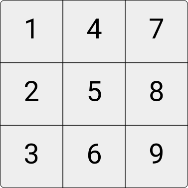

## Data structures: matrices/arrays

Example:

```r
my_matrix <- matrix(
  c(1,2,3,4,5,6),
  nrow = 3,
  byrow = FALSE
)
my_matrix
```

```
     [,1] [,2]
[1,]    1    4
[2,]    2    5
[3,]    3    6
```

```r
dim(my_matrix)
```

```
[1] 3 2
```

## Data structures: arrays

Arrays are **higher-dimensional** collections of values of the same type

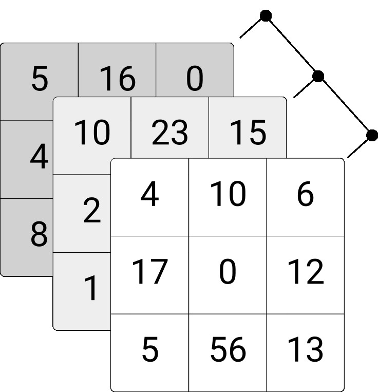

## Data structures: matrices/arrays

Example:

```r
my_array <- array(1:12, dim = c(2, 3, 2))
my_array
```

```
, , 1

     [,1] [,2] [,3]
[1,]    1    3    5
[2,]    2    4    6

, , 2

     [,1] [,2] [,3]
[1,]    7    9   11
[2,]    8   10   12
```

## Data frames, tibbles, and data tables

- Each column contains a vector of a given data type (or factor), but all columns need to be of identical length.
- Under the hood, a data frame is a list of equal-length vectors.
- `data.frame`, `tibble`, `data.table`

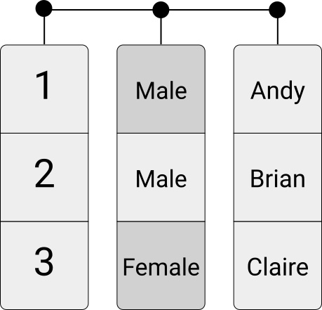

## Data frames, tibbles, and data tables

Example:

```r
df <- data.frame(person = persons, age = ages, gender = c(0,1,1))
df
```

```
  person age gender
1   Andy  24      0
2  Brian  50      1
3   Andy  30      1
```

## Data structures: lists

Lists can contain different data types in each element, or even different data structures of different dimensions.

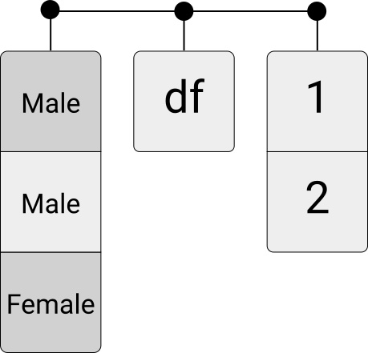

## Data structures: lists

Example:

```r
my_list <- list(my_array, my_matrix, df)
my_list
```

```
[[1]]
, , 1

     [,1] [,2] [,3]
[1,]    1    3    5
[2,]    2    4    6

, , 2

     [,1] [,2] [,3]
[1,]    7    9   11
[2,]    8   10   12


[[2]]
     [,1] [,2]
[1,]    1    4
[2,]    2    5
[3,]    3    6

[[3]]
  person age gender
1   Andy  24      0
2  Brian  50      1
3   Andy  30      1
```

## Data structures: lists

[figure not shown]

## Data attributes

Most common attributes:

- names and dimnames
- dim
- class
- levels
- length

## Data attributes

```r
x <- c(a=1, b=2, c=3)
names(x)
```

```
[1] "a" "b" "c"
```

```r
m <- matrix(1:6, nrow=2)
dim(m)
```

```
[1] 2 3
```

```r
dimnames(m) <- list(c("row1", "row2"), c("col1", "col2", "col3"))
m
```

```
     col1 col2 col3
row1    1    3    5
row2    2    4    6
```

## Data structures: factors

- Factors are sets of categories.
- The values come from a fixed set of possible values.

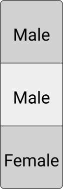

## Data structures: factors

Example:

```r
gender <- factor(c("Male", "Male", "Female"))
gender
```

```
[1] Male   Male   Female
Levels: Female Male
```

Factors are “disguised” integers…

```r
typeof(gender)
```

```
[1] "integer"
```

## Data structures: factors

Two components:

- the integer (or “levels”);
- the labels.

```r
levels(gender)
```

```
[1] "Female" "Male"
```

## Dates 🔎

📆 Dates are “disguised” doubles… that counts the number of days since 01.01.1970

```r
d <- as.Date(c("2026-10-01", "1936-10-08"))
typeof(d)
## [1] "double"
class(d)
## [1] "Date"
as.numeric(d)
## [1]  20727 -12138
```

You can compute with them:

```r
d[2] - d[1]
## Time difference of -32865 days
d + 7
## [1] "2026-10-08" "1936-10-15"
```

And indicate which format you are using:

```r
as.Date("01.10.2026", format = "%d.%m.%Y")
## [1] "2026-10-01"
```

## Dates and times 🔎

⏲️ A date-time is a “disguised” double too: seconds since 1970-01-01, plus a time zone.

```r
x <- as.POSIXct("2026-10-01 17:30",
                tz = "Europe/Zurich")
typeof(x)
## [1] "double"
class(x)
## [1] "POSIXct" "POSIXt"
as.numeric(x)
## [1] 1790868600
```

For any date-time format, I recommend `lubridate`!

```r
library(lubridate)
dmy_hm("01.10.2026 17:30", tz = "Europe/Zurich")
## [1] "2026-10-01 17:30:00 CEST"
```

> **Note:** Always set the time zone (`tz`). Without it, R uses your computer’s time zone, and the same file can give different times on different laptops.

# Manipulating rectangular data in R

## Loading built-in datasets

Load the built-in `swiss` dataset using the `data()`-function.

```r
data(swiss)
```

Famous built-in datasets are `mtcars`, `iris`, `USArrests`, etc. The `swiss` dataset is loaded from the package `datasets`, which can be installed with the command `install.packages("datasets")`. Description of the dataset is [here](https://stat.ethz.ch/R-manual/R-devel/library/datasets/html/swiss.html).

## Manipulations with data frames

```r
# inspect the structure
str(swiss)
```

```
'data.frame':   47 obs. of  6 variables:
 $ Fertility       : num  80.2 83.1 92.5 85.8 76.9 76.1 83.8 92.4 82.4 82.9 ...
 $ Agriculture     : num  17 45.1 39.7 36.5 43.5 35.3 70.2 67.8 53.3 45.2 ...
 $ Examination     : int  15 6 5 12 17 9 16 14 12 16 ...
 $ Education       : int  12 9 5 7 15 7 7 8 7 13 ...
 $ Catholic        : num  9.96 84.84 93.4 33.77 5.16 ...
 $ Infant.Mortality: num  22.2 22.2 20.2 20.3 20.6 26.6 23.6 24.9 21 24.4 ...
```

```r
# look at the first few rows
head(swiss, n = 5)
```

```
             Fertility Agriculture Examination Education Catholic Infant.Mortality
Courtelary        80.2        17.0          15        12     9.96             22.2
Delemont          83.1        45.1           6         9    84.84             22.2
Franches-Mnt      92.5        39.7           5         5    93.40             20.2
Moutier           85.8        36.5          12         7    33.77             20.3
Neuveville        76.9        43.5          17        15     5.16             20.6
```

## Work with data.frames

#### Select columns

```r
swiss$Fertility # use the $-operator
```

```r
swiss[, 1] # use brackets [] and the column number/index
```

```r
swiss[, "Fertility"] # use the name of the column
```

```r
swiss[, c("Fertility", "Agriculture")] # use the name of the column
```

#### Select rows

```r
swiss[1,]  # First row
```

```r
swiss[swiss$Fertility > 40,]  # Based on condition ("filter")
```

# Other Common Rectangular Formats 🔎

## Spreadsheets/Excel

Needs the additional R-package: `readxl`. Then we use the package’s `read_excel()`-function to import data from an excel-sheet.

[figure not shown]

```r
# install the package
install.packages("readxl")

# load the package
library(readxl)

# import data from a spreadsheet
swiss_imported <- read_excel("data/swiss.xlsx")
```

## Write an Excel Spreadsheet

- Use [`openxlsx`](https://ycphs.github.io/openxlsx/) to write, style, and edit .xlsx files.
- Alternative to the xlsx package with no dependency on Java.

[figure not shown]

## Data from other data analysis software

#### STATA, SPSS, etc.

- Additional packages needed: `foreign`, `haven`, etc.
- Parsers (functions) for many foreign formats.
  - For example, `read_spss()` for SPSS’ `.sav`-format.

```r
# Load library
library(haven)

# Read file from SPSS
swiss_imported <- read_spss("data/swiss.sav")
```

# Exercise 🔎

## Exercise

- Download the `financial_data.txt` from Canvas

# Appendix: a side note on data frames and tibbles

## Rectangular data in R and tidyverse

- data frames: base `R`
- tibbles: `tidyverse`

## Tibbles are a modern version of data frames

A tibble is a data frame with a few small changes.

- You will meet tibbles as soon as you use the `tidyverse`: `read_csv()`, for example, gives you one.
- A tibble holds the same data as a data frame.
- The differences are in how it prints and in a few details of how it behaves.
- See [**Tibble vs. DataFrame**](https://jtr13.github.io/cc21fall1/tibble-vs.-dataframe.html#tibble-vs.-dataframe) for more details.

## A tibble prints the first 10 rows

```r
as_tibble(swiss)
```

```
# A tibble: 47 × 6
   Fertility Agriculture Examination Education Catholic Infant.Mortality
       <dbl>       <dbl>       <int>     <int>    <dbl>            <dbl>
 1      80.2        17            15        12     9.96             22.2
 2      83.1        45.1           6         9    84.8              22.2
 3      92.5        39.7           5         5    93.4              20.2
 4      85.8        36.5          12         7    33.8              20.3
 5      76.9        43.5          17        15     5.16             20.6
 6      76.1        35.3           9         7    90.6              26.6
 7      83.8        70.2          16         7    92.8              23.6
 8      92.4        67.8          14         8    97.2              24.9
 9      82.4        53.3          12         7    97.7              21
10      82.9        45.2          16        13    91.4              24.4
# ℹ 37 more rows
```

## A data frame prints every row

```r
as.data.frame(swiss)
```

```
             Fertility Agriculture Examination Education Catholic Infant.Mortality
Courtelary        80.2        17.0          15        12     9.96             22.2
Delemont          83.1        45.1           6         9    84.84             22.2
Franches-Mnt      92.5        39.7           5         5    93.40             20.2
Moutier           85.8        36.5          12         7    33.77             20.3
Neuveville        76.9        43.5          17        15     5.16             20.6
Porrentruy        76.1        35.3           9         7    90.57             26.6
Broye             83.8        70.2          16         7    92.85             23.6
Glane             92.4        67.8          14         8    97.16             24.9
Gruyere           82.4        53.3          12         7    97.67             21.0
Sarine            82.9        45.2          16        13    91.38             24.4
Veveyse           87.1        64.5          14         6    98.61             24.5
Aigle             64.1        62.0          21        12     8.52             16.5
Aubonne           66.9        67.5          14         7     2.27             19.1
Avenches          68.9        60.7          19        12     4.43             22.7
Cossonay          61.7        69.3          22         5     2.82             18.7
Echallens         68.3        72.6          18         2    24.20             21.2
Grandson          71.7        34.0          17         8     3.30             20.0
Lausanne          55.7        19.4          26        28    12.11             20.2
La Vallee         54.3        15.2          31        20     2.15             10.8
Lavaux            65.1        73.0          19         9     2.84             20.0
Morges            65.5        59.8          22        10     5.23             18.0
Moudon            65.0        55.1          14         3     4.52             22.4
Nyone             56.6        50.9          22        12    15.14             16.7
Orbe              57.4        54.1          20         6     4.20             15.3
Oron              72.5        71.2          12         1     2.40             21.0
Payerne           74.2        58.1          14         8     5.23             23.8
Paysd'enhaut      72.0        63.5           6         3     2.56             18.0
Rolle             60.5        60.8          16        10     7.72             16.3
Vevey             58.3        26.8          25        19    18.46             20.9
Yverdon           65.4        49.5          15         8     6.10             22.5
Conthey           75.5        85.9           3         2    99.71             15.1
Entremont         69.3        84.9           7         6    99.68             19.8
Herens            77.3        89.7           5         2   100.00             18.3
Martigwy          70.5        78.2          12         6    98.96             19.4
Monthey           79.4        64.9           7         3    98.22             20.2
St Maurice        65.0        75.9           9         9    99.06             17.8
Sierre            92.2        84.6           3         3    99.46             16.3
Sion              79.3        63.1          13        13    96.83             18.1
Boudry            70.4        38.4          26        12     5.62             20.3
La Chauxdfnd      65.7         7.7          29        11    13.79             20.5
Le Locle          72.7        16.7          22        13    11.22             18.9
Neuchatel         64.4        17.6          35        32    16.92             23.0
Val de Ruz        77.6        37.6          15         7     4.97             20.0
ValdeTravers      67.6        18.7          25         7     8.65             19.5
V. De Geneve      35.0         1.2          37        53    42.34             18.0
Rive Droite       44.7        46.6          16        29    50.43             18.2
Rive Gauche       42.8        27.7          22        29    58.33             19.3
```

## Tibbles vs data frames

- **Printing:** a tibble shows the first 10 rows and the columns that fit on your screen. A data frame prints everything.
- **Shortened column names:** `swiss$Fert` finds the column `Fertility` in a data frame. A tibble gives a warning and returns `NULL`.
- **Selecting one column with `[ ]`:** `df[, "x"]` gives a vector for a data frame, but a one-column tibble for a tibble. `df$x` gives a vector for both.
- **Adding a column:** a data frame and a tibble do not repeat values in the same way (next slide).

Source: https://jtr13.github.io/cc21fall1/tibble-vs.-dataframe.html

## Tibbles vs data frames: repeating values

If a new column is shorter than the data, R may repeat its values to fill the column (*“recycling”*).

#### Data frame

```r
df <- data.frame(id = 1:4)
df$country <- "CH"
df$group <- c("a", "b")
df
```

```
  id country group
1  1      CH     a
2  2      CH     b
3  3      CH     a
4  4      CH     b
```

#### Tibble

```r
tb <- tibble(id = 1:4)
tb$country <- "CH"
tb$group <- c("a", "b")
```

```
Error in `$<-`:
! Assigned data `c("a", "b")` must be compatible with existing data.
✖ Existing data has 4 rows.
✖ Assigned data has 2 rows.
ℹ Only vectors of size 1 are recycled.
Caused by error in `vectbl_recycle_rhs_rows()`:
! Can't recycle input of size 2 to size 4.
```

```r
tb
```

```
# A tibble: 4 × 2
     id country
  <int> <chr>
1     1 CH
2     2 CH
3     3 CH
4     4 CH
```

#### A tibble only repeats a single value. A data frame also repeats longer inputs if they fit evenly, with no warning.